# Assignment5

2023-10-26

## Assignment 5 - k-Means Algorithm

- Load needed libraries: tidyverse, stats, ggfortify and factoextra

  ```r
  library(tidyverse)
  library(stats)
  library(ggfortify)
  library(factoextra)
  ```

1. Load the dataset mammal_Sleep.csv into a data frame.

   ```r
   df_sleep <- read.csv("mammal_Sleep.csv")
   ```

2. Create a new data frame sleep_data with sleep_total and sleep_rem.

   ```r
   sleep_data <- df_sleep[,7:8]
   ```

- Check for incomplete cases

  ```r
  sleep_data %>%
    filter(!complete.cases(.)) %>%
    view
  ```

- There are 22 cases with NA in sleep_rem. These will be replaced with the mean value for sleep_rem.
- Calculate the mean and median value for sleep_rem

  ```r
  mean_sleep_rem <- mean(sleep_data$sleep_rem, na.rm = TRUE)
  median_sleep_rem <- median(sleep_data$sleep_rem, na.rm = TRUE)
  mean_sleep_rem
  ```

  ```
  ## [1] 1.87541
  ```

  ```r
  median_sleep_rem
  ```

  ```
  ## [1] 1.5
  ```

- These values are quite close. Graph a histogram of the sleep_rem variable to examine its distribution:

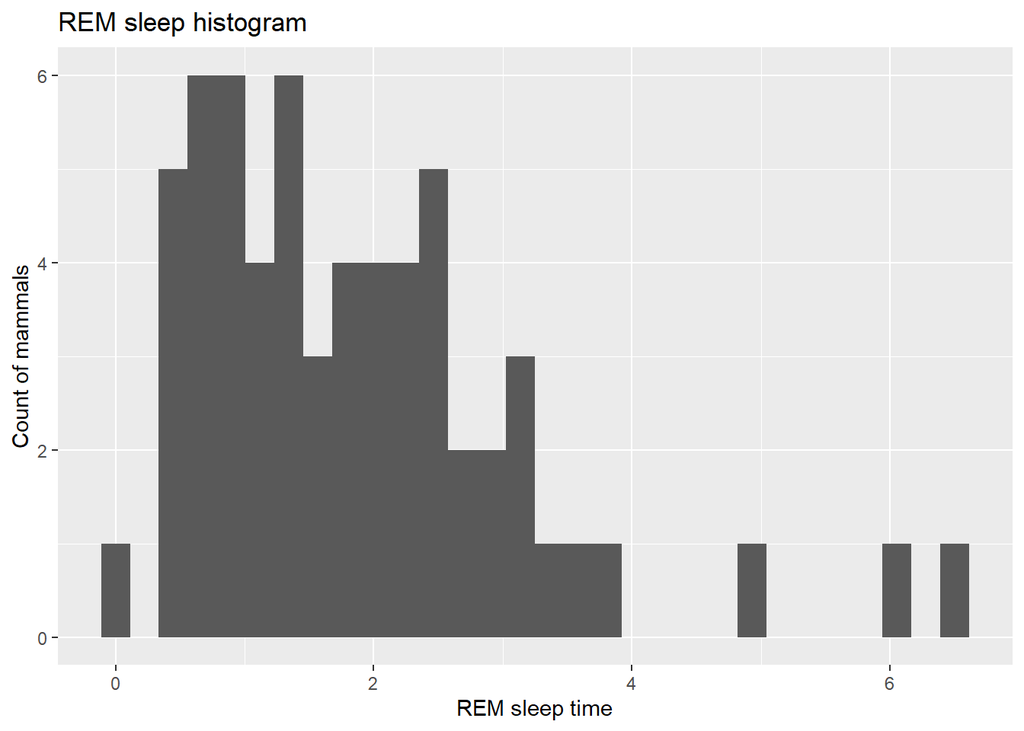

  ```r
  df_sleep %>%
    ggplot(mapping=aes(x=sleep_rem)) +
    geom_histogram() +
    labs(title="REM sleep histogram",
         x = "REM sleep time",
         y = "Count of mammals")
  ```

- This histogram of sleep_rem shows it is somewhat right skewed, but there shouldn’t be much difference whether mean or median is used to replace NA values.
- Replace sleep_rem with NA by mean sleep_rem using replace_na

  ```r
  sleep_data <- sleep_data %>%
    replace_na(list(sleep_rem = mean_sleep_rem))
  ```

- Check again for incomplete cases

  ```r
  sleep_data %>%
    filter(!complete.cases(.)) %>%
    view
  ```

- No Incomplete cases
- Scale the dataset

  ```r
  sleep_data_scale <- scale(sleep_data)
  ```

- Use three different graphs to evaluate how many clusters should be used
- First use ‘wss’ plot. The elbow shows the suggested number of clusters.

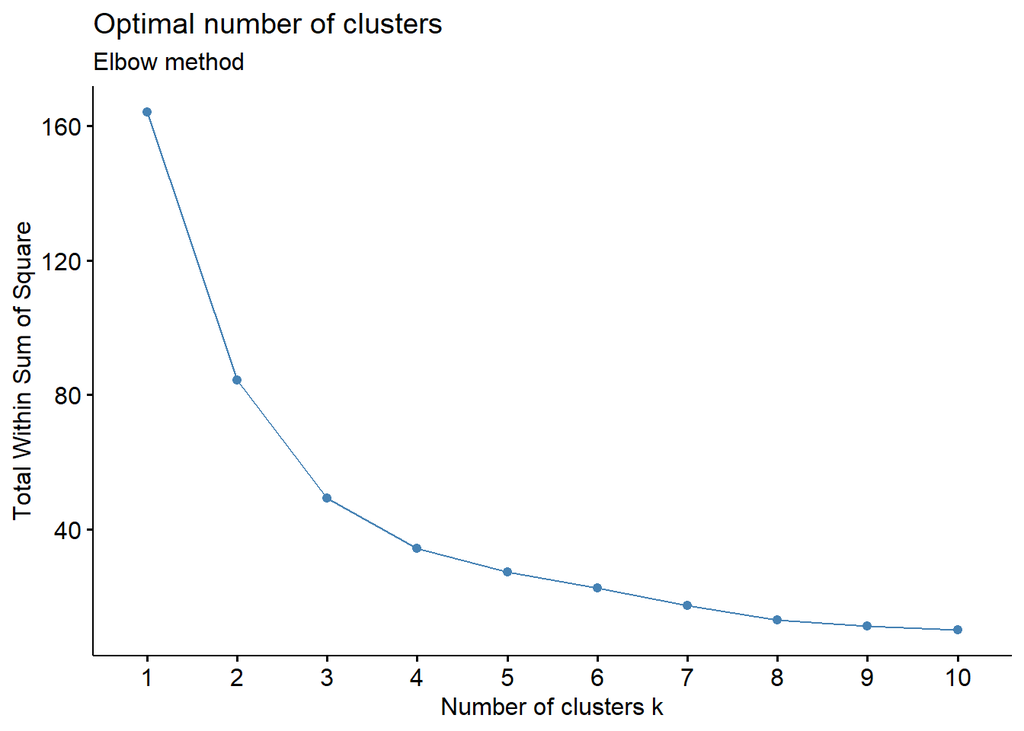

  ```r
  fviz_nbclust(sleep_data_scale, kmeans, method="wss") +
    labs(subtitle = "Elbow method")
  ```

- Next the ‘silhouette’ method

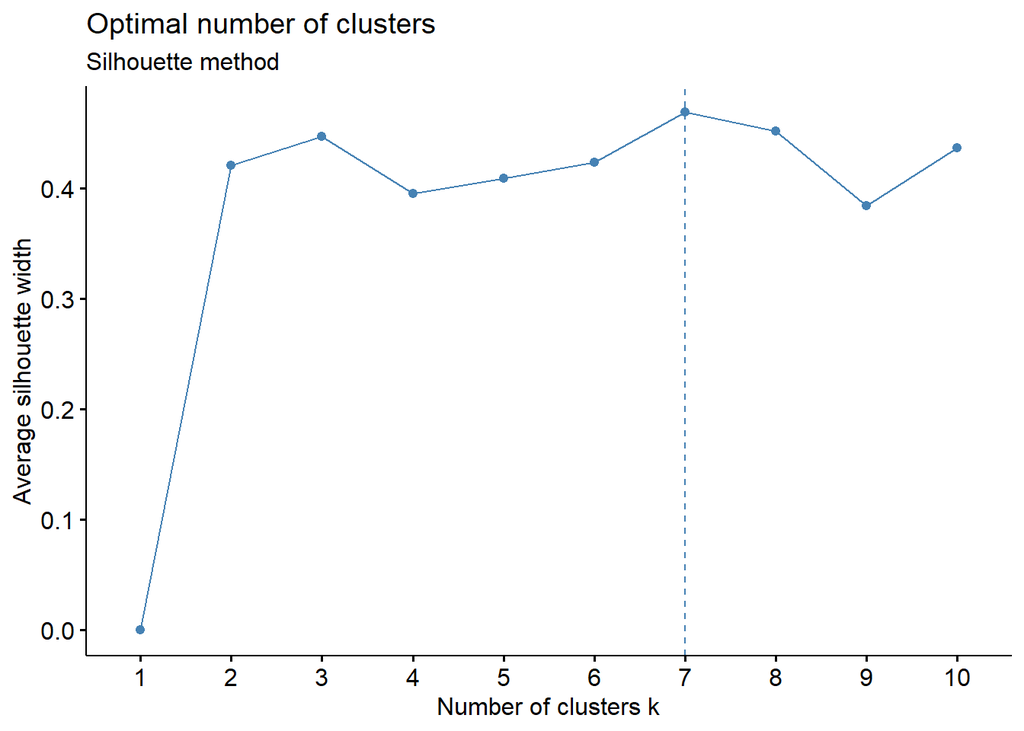

  ```r
  fviz_nbclust(sleep_data_scale, kmeans, method="silhouette") +
    labs(subtitle = "Silhouette method")
  ```

- Finally the ‘gap stat’ method

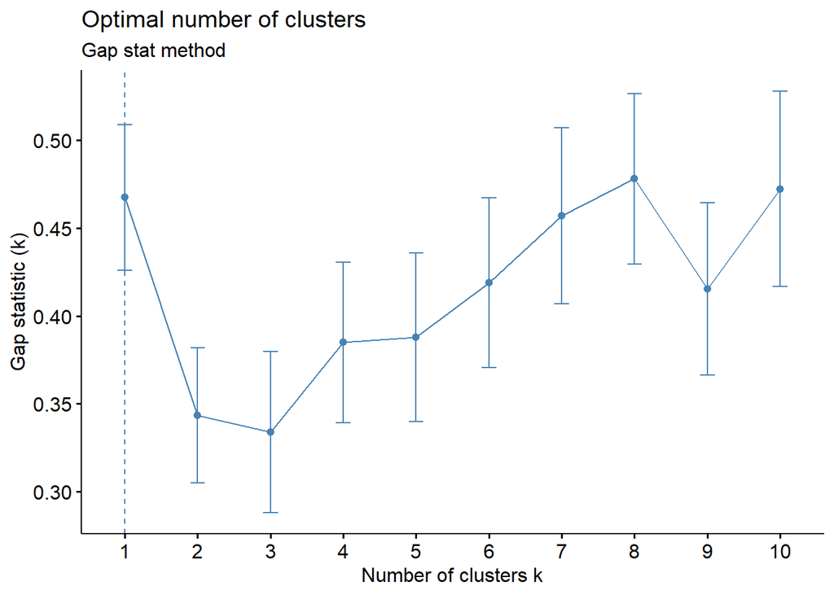

  ```r
  fviz_nbclust(sleep_data_scale, kmeans, method="gap_stat") +
    labs(subtitle = "Gap stat method")
  ```

3. Fit a k-means clustering model with 4 clusters to the data subset sleep_data scale.

```r
sleep_model_km <- kmeans(sleep_data_scale, centers=4, nstart =10)
```

- Use ‘autoplot’ to graph clusters, first with a boundary around the clusters.

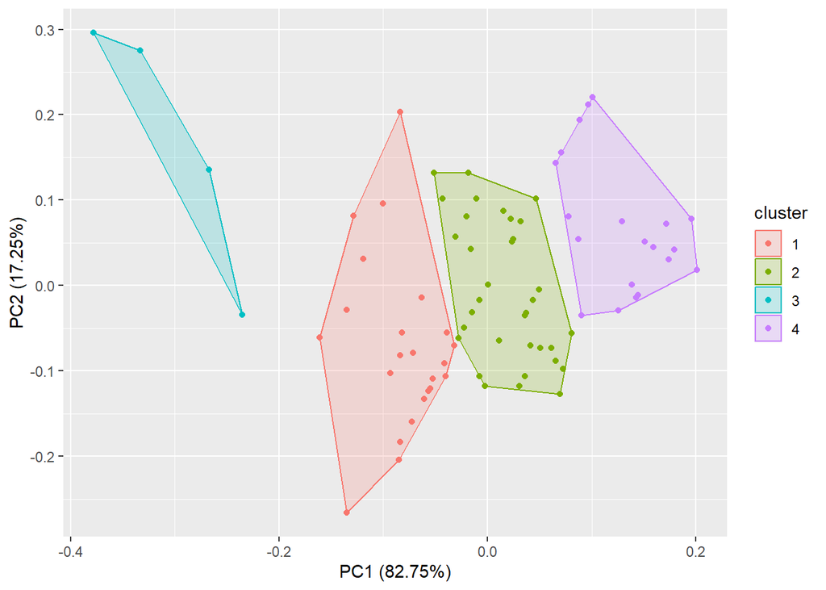

  ```r
  autoplot(sleep_model_km, sleep_data_scale, frame = TRUE)
  ```

- Plot with autoplot again with no boundary around the clusters.

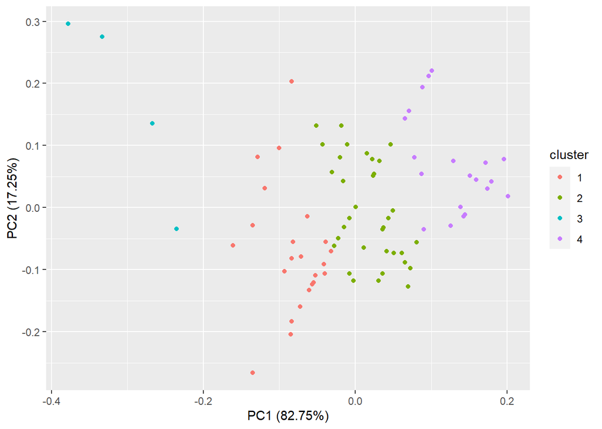

  ```r
  autoplot(sleep_model_km, sleep_data_scale)
  ```

- The axes on these plots are labeled ‘PC1’ and ‘PC2’, meaning they use principal components to display the clusters.
- Use ‘fviz_cluster’ to display the cluster against the scaled values of ‘sleep_total’ and ‘sleep_rem.’

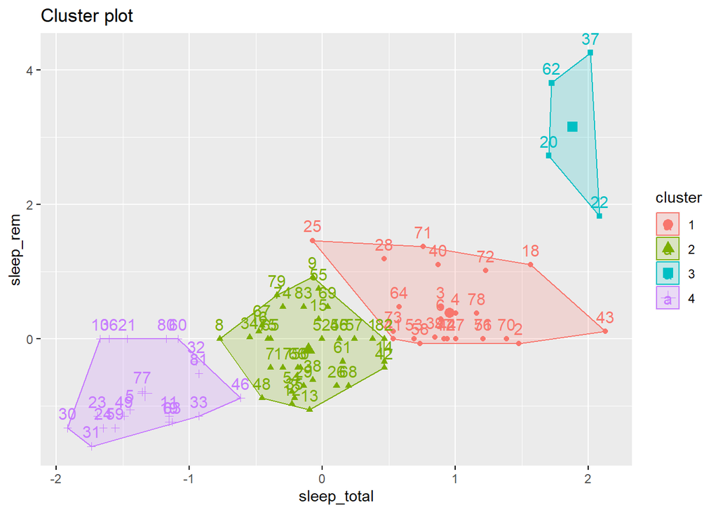

  ```r
  km.clusters <- sleep_model_km$cluster
  fviz_cluster(list(data=sleep_data_scale,
                    cluster = km.clusters))
  ```

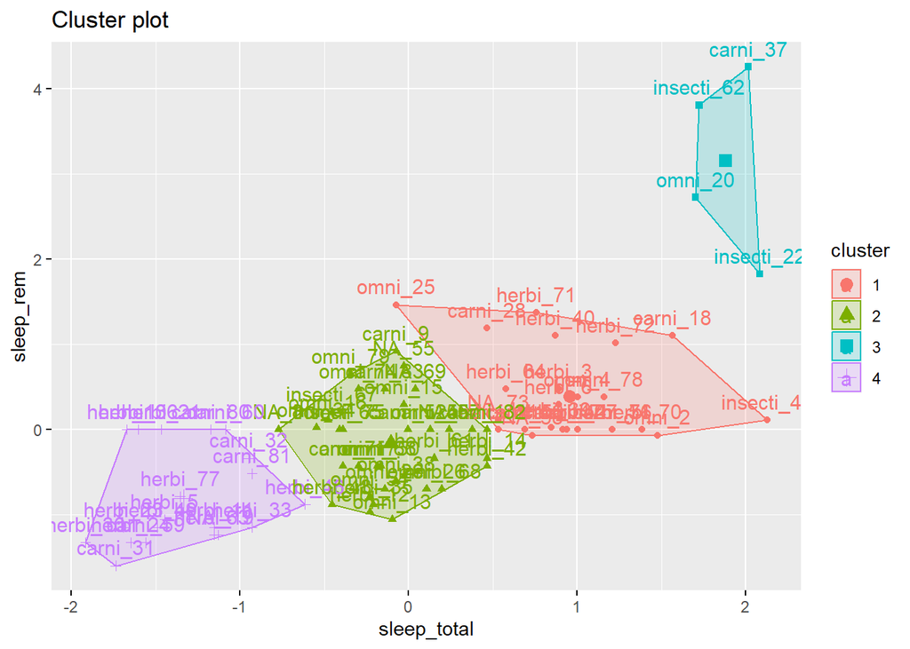

  ```r
  rownames(sleep_data_scale) <- paste(df_sleep$vore,
                                1:dim(df_sleep)[1],
                                sep="_")
  fviz_cluster(list(data=sleep_data_scale,
                    cluster = km.clusters))
  ```

- We can also use a table to see how the ‘vore’ variable is divided into clusters:

  ```r
  table(km.clusters, df_sleep$vore)
  ```

  ```
  ##
  ## km.clusters carni herbi insecti omni
  ##           1     5    12       1    4
  ##           2     7     7       2   15
  ##           3     1     0       2    1
  ##           4     6    13       0    0
  ```

- This shows the clusters partially separate mammals by ‘vore’, but there is are also multiple vore features in each cluster, so perhaps other variables could also be considered to examine their relationship to these clusters.